# IE 360 - HW 1

Irmak Dai

April 16, 2021

# 1 Introduction

The research question I decided on is "Is the probability of buying a car is related to the interest rate for vehicle loans, dollar exchange rate, and/or total automobile production. In other words, I would like to understand what influences people to consider buying a car.

From [EVDS](https://evds2.tcmb.gov.tr/index.php?/evds/serieMarket), I used these data categories:

- Surveys
  - Seasonally unadjusted Consumer Confidence Index and Indices of Consumer Tendency Survey Questions
    - The probability of buying a car (over the next 12 months)
- Production Statistics
  - Subscribe Total Cars Production (AMA=Automotive Manufacturers Association)
    - (AMA) Automobile (Unit)
- Interest rates
  - Weighted Average Interest Rates For Bank Loans (Flow Data, %))
    - Vehicle (TRY)(Flow Data, %)
- Exchange rates
  - Exchange rates
    - (USD) US Dollar (Buying)

From [Google Trends](https://trends.google.com/), I used these interest data of searches:

- “Araba Fiyat” for the probability of buying a car
- “Turk Uretimi Araba” for the automobile production
- “Arac Kredi” for vehicle loan interest rate
- “USD TRY” for US dollar exchange rate

Monthly data for the time period of 2012.01-2021.02 is used.

# 2 Loading the data & preparation

Loading the required packages:

```r
library(EVDS)
library(zoo)
library(lubridate)
library(dplyr)
library(ggplot2)
Sys.setlocale("LC_TIME", "English")
```

Getting the time series data from EVDS:

```r
df <- get_series(series = c("TP.TG2.Y17", "TP.UR.S08","TP.KTF11", "TP.DK.USD.A.YTL"),start_date = "01-01-2012", end_date = "01-02-2021")

df1 <- df$items %>%
  mutate(Date=as.yearmon(Tarih, "%Y-%m"),prob_of_buying_car=as.numeric(TP_TG2_Y17),total_automobile_production=as.numeric(TP_UR_S08), interest_rate_for_vehicle_loan=as.numeric(TP_KTF11), USD_TRY=as.numeric(TP_DK_USD_A_YTL) )%>%
  select(Date:USD_TRY)
```

Preparing the Google Trends data:

```r
setwd("C:/Users/Asus/Desktop/Spring 2021/IE 360/HW1")
gt <- read.csv("arabafiyat.csv", row.names = NULL)
gt <- as.data.frame(gt)
gt <- gt[-1, ]
gt1 <- gt %>%
  mutate(Date=as.yearmon(row.names), interest_over_time=as.numeric(Kategori..TÃ.m.kategoriler)) %>%
  select(Date:interest_over_time)

arackredi <- read.csv("arackredi.csv", row.names = NULL)
arackredi <- as.data.frame(arackredi)
arackredi <- arackredi[-1, ]

gt2 <- arackredi %>%
  mutate(Date=as.yearmon(row.names), interest_over_time=as.numeric(Kategori..TÃ.m.kategoriler)) %>%
  select(Date:interest_over_time)

turk_uretimi_araba <- read.csv("turk_uretimi_araba.csv", row.names = NULL)
turk_uretimi_araba <- as.data.frame(turk_uretimi_araba)
turk_uretimi_araba <- turk_uretimi_araba[-1, ]

gt3 <- turk_uretimi_araba %>%
  mutate(Date=as.yearmon(row.names), interest_over_time=as.numeric(Kategori..TÃ.m.kategoriler)) %>%
  select(Date:interest_over_time)

USD_TRY <- read.csv("USD_TRY.csv", row.names = NULL)
USD_TRY <- as.data.frame(USD_TRY)
USD_TRY <- USD_TRY[-1, ]

gt4 <- USD_TRY %>%
  mutate(Date=as.yearmon(row.names), interest_over_time=as.numeric(Kategori..TÃ.m.kategoriler)) %>%
  select(Date:interest_over_time)
```

Merging the dataframes in order to plot the scatter plots easily:

```r
merged <- df1 %>%
  inner_join(gt1, by='Date') %>%
  inner_join(gt2, by='Date', suffix=c("","_arac_kredi")) %>%
  inner_join(gt3, by='Date', suffix=c("","_turk_uretimi_araba")) %>%
  inner_join(gt4, by='Date', suffix=c("","_USD_TRY"))

names(merged)[6]="interest_over_time_araba_fiyat"
```

# 3 Data Visualization

## 3.1 Probability of buying a car

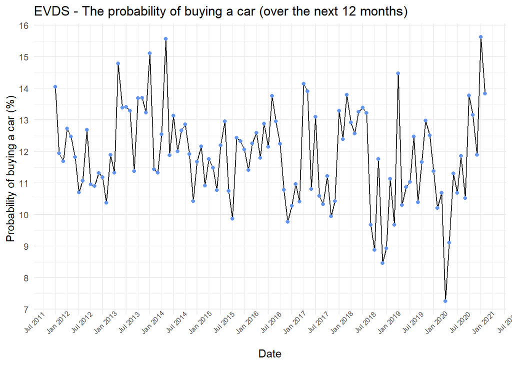

```r
ggplot(df1, aes(x=Date,y=prob_of_buying_car))+
  geom_line()+
  theme_minimal()+
  labs(x="Date", y="Probability of buying a car (%)", title = "EVDS - The probability of buying a car (over the next 12 months)")+
  theme(axis.text.x = element_text(angle=45,size=7))+
  scale_x_yearmon(n=18)+
  scale_y_continuous(breaks=seq(0,20,by=1))+
  geom_point(color="cornflowerblue")
```

There is not a clear pattern. The series have many ups and downs.

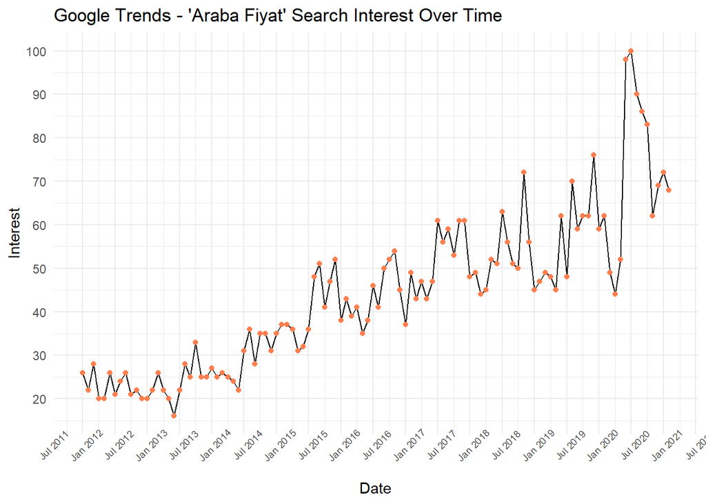

```r
ggplot(gt1, aes(x=Date,y=interest_over_time))+
  geom_line()+
  theme_minimal()+
  labs(x="Date", y="Interest", title = "Google Trends - 'Araba Fiyat' Search Interest Over Time")+
  theme(axis.text.x = element_text(angle=45,size=7))+
  scale_x_yearmon(n=18)+
  scale_y_continuous(breaks=seq(0,100,by=10))+
  geom_point(color="coral")
```

We see an increasing trend with fluctuations, which may be explained by the spread of technology.

Let’s compare the plots. For example between July 2020-Jan 2021 the probability of buying a car has an increasing trend. Surprisingly the search interest has a decreasing trend. We also see that both plots have some common local minimums and maximums, for example April 2020 and January 2021.

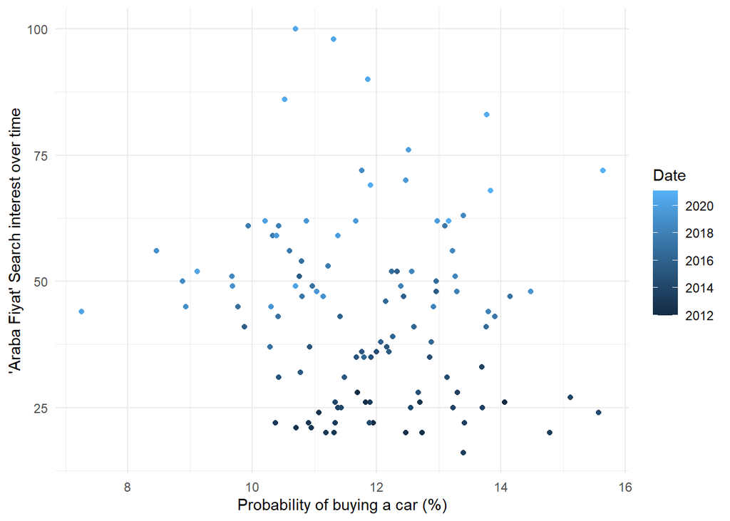

```r
ggplot(merged)+
  geom_point(aes(x=prob_of_buying_car,y=interest_over_time_araba_fiyat, color=as.Date(Date)))+
  theme_minimal()+
  labs(x="Probability of buying a car (%)", y="'Araba Fiyat' Search interest over time", color="Date")
```

We do not see a clear correlatiOn.

## 3.2 Total automobile production

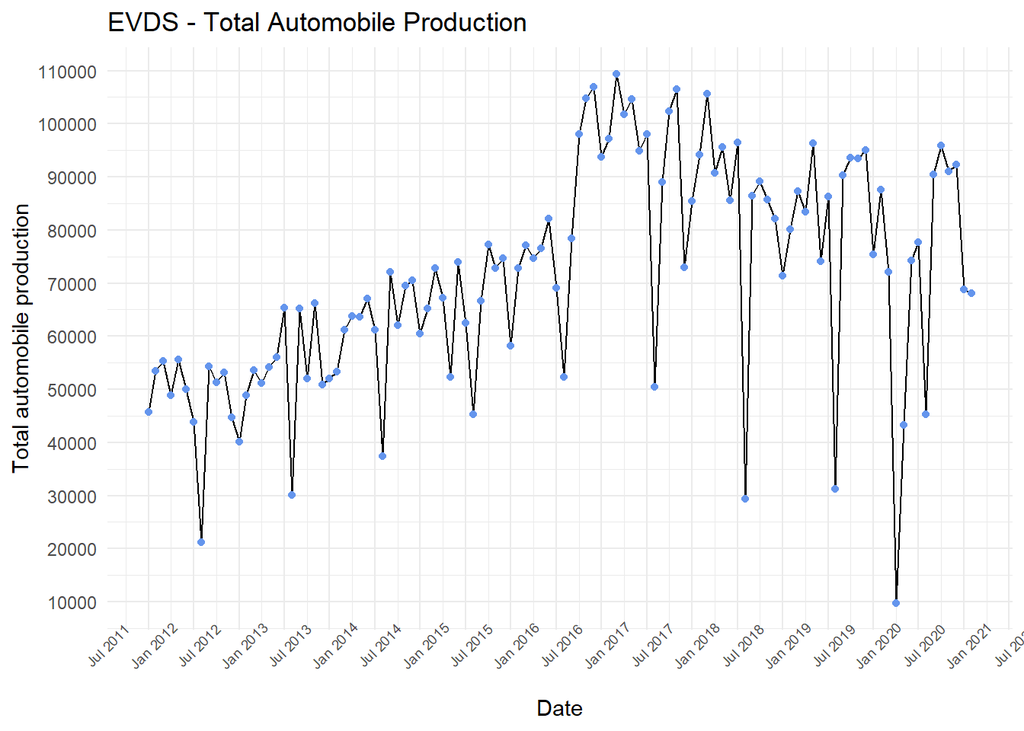

```r
ggplot(df1, aes(x=Date,y=total_automobile_production))+
  geom_line()+
  theme_minimal()+
  labs(x="Date", y="Total automobile production", title="EVDS - Total Automobile Production")+
  theme(axis.text.x = element_text(angle=45,size=7))+
  scale_x_yearmon(n=18)+
  scale_y_continuous(breaks = seq(0, 120000, by = 10000))+
  geom_point(color="cornflowerblue")
```

The volume of production hits the bottom in every August. Also we can see the effect of Covid-19 pandemic in April 2020. It can be remarked that April 2020 was also the time when the probability of buying a car is minimum.

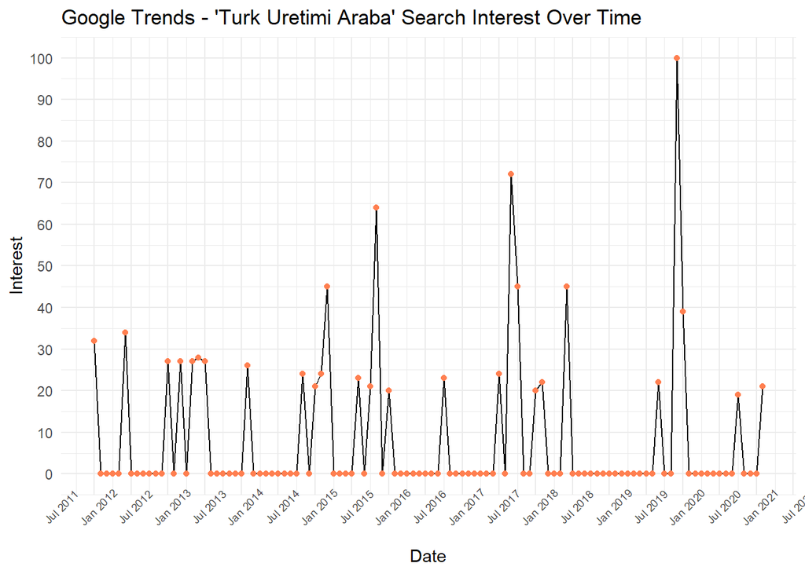

```r
ggplot(gt3, aes(x=Date,y=interest_over_time))+
  geom_line()+
  theme_minimal()+
  labs(x="Date", y="Interest", title = "Google Trends - 'Turk Uretimi Araba' Search Interest Over Time")+
  theme(axis.text.x = element_text(angle=45,size=7))+
  scale_x_yearmon(n=18)+
  scale_y_continuous(breaks=seq(0,100,by=10))+
  geom_point(color="coral")
```

Although I tried many search queries, none of them were popular enough. There are many data points where interest could not be measured.

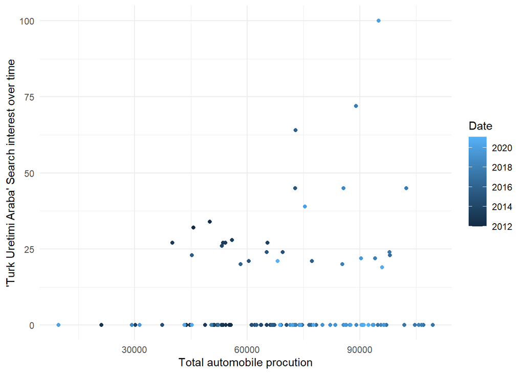

```r
ggplot(merged)+
  geom_point(aes(x=total_automobile_production,y=interest_over_time_turk_uretimi_araba, color=as.Date(Date)))+
  theme_minimal()+
  labs(x="Total automobile procution", y="'Turk Uretimi Araba' Search interest over time", color="Date")
```

## 3.3 Interest rate for vehicle loans

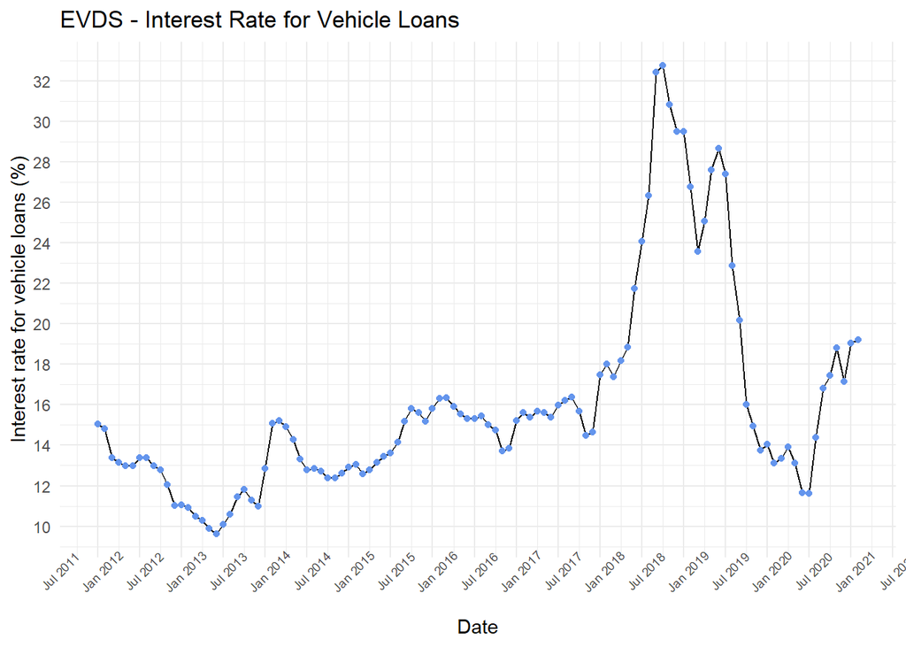

```r
ggplot(df1, aes(x=Date,y=interest_rate_for_vehicle_loan))+
  geom_line()+
  theme_minimal()+
  labs(x="Date", y="Interest rate for vehicle loans (%)", title="EVDS - Interest Rate for Vehicle Loans")+
  theme(axis.text.x = element_text(angle=45,size=7))+
  scale_x_yearmon(n=18)+
  scale_y_continuous(breaks=seq(0,40,by=2))+
  geom_point(color="cornflowerblue")
```

Until 2018 there have been no dramatic changes in the interest rate for vehicle loans.

[figure not shown]

```r
ggplot(gt2, aes(x=Date,y=interest_over_time))+
  geom_line()+
  theme_minimal()+
  labs(x="Date", y="Interest", title = "Google Trends - 'Arac Kredi' Search Interest Over Time")+
  theme(axis.text.x = element_text(angle=45,size=7))+
  scale_x_yearmon(n=18)+
  scale_y_continuous(breaks=seq(0,100,by=10))+
  geom_point(color="coral")
```

The increases in October 2019 and June 2020 are interesting. When we check corresponding interest rates they are lower in their time period.

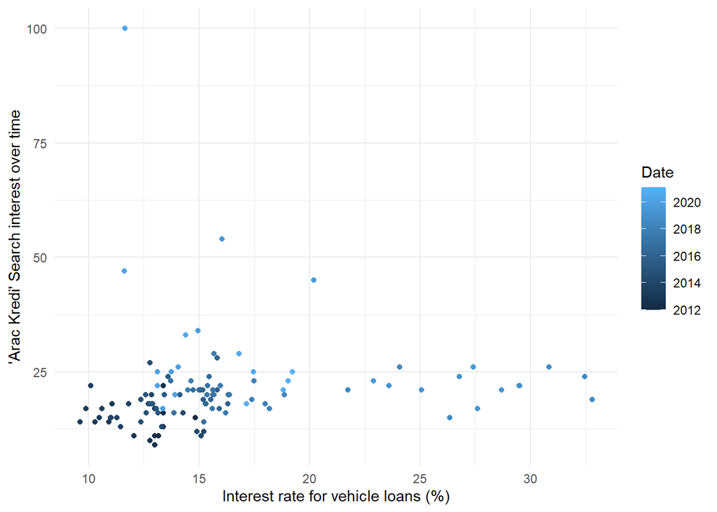

```r
ggplot(merged)+
  geom_point(aes(x=interest_rate_for_vehicle_loan,y=interest_over_time_arac_kredi, color=as.Date(Date)))+
  theme_minimal()+
  labs(x="Interest rate for vehicle loans (%)", y="'Arac Kredi' Search interest over time", color="Date")
```

## 3.4 USD TRY rate

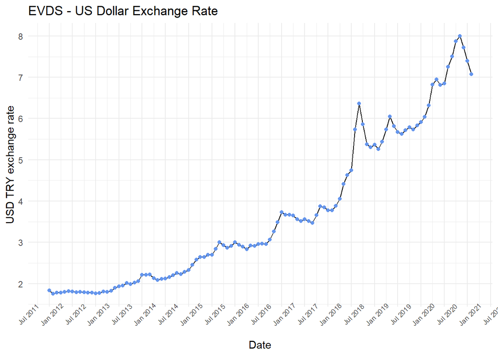

```r
ggplot(df1, aes(x=Date,y=USD_TRY))+
  geom_line()+
  theme_minimal()+
  labs(x="Date", y="USD TRY exchange rate", title = "EVDS - US Dollar Exchange Rate")+
  theme(axis.text.x = element_text(angle=45,size=7))+
  scale_x_yearmon(n=18)+
  scale_y_continuous(breaks=seq(0,10,by=1))+
  geom_point(color="cornflowerblue")
```

A obvious increasing trend is observed.

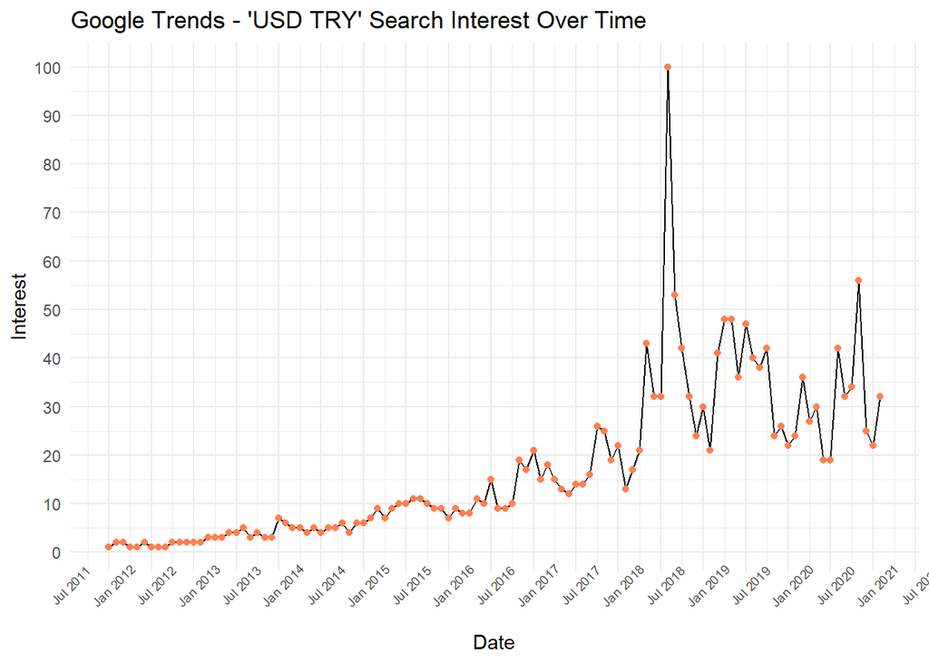

```r
ggplot(gt4, aes(x=Date,y=interest_over_time))+
  geom_line()+
  theme_minimal()+
  labs(x="Date", y="Interest", title = "Google Trends - 'USD TRY' Search Interest Over Time")+
  theme(axis.text.x = element_text(angle=45,size=7))+
  scale_x_yearmon(n=18)+
  scale_y_continuous(breaks=seq(0,100,by=10))+
  geom_point(color="coral")
```

When the dramatic increases of the interest is checked, it is seen they correspond to the dramatic increases in the exchange rate. For example in August 2018.

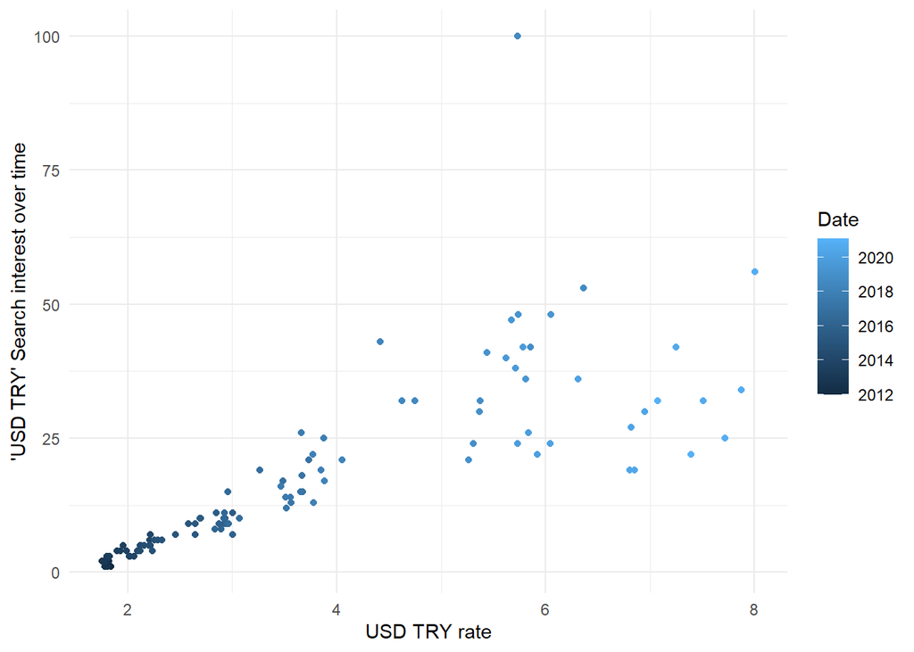

```r
ggplot(merged)+
  geom_point(aes(x=USD_TRY,y=interest_over_time_USD_TRY, color=as.Date(Date)))+
  theme_minimal()+
  labs(x="USD TRY rate", y="'USD TRY' Search interest over time", color="Date")
```

We can say that USD TRY exchange rate is correlated with the volume of Google searches of the query ‘USD TRY’.

# 4 Conclusion

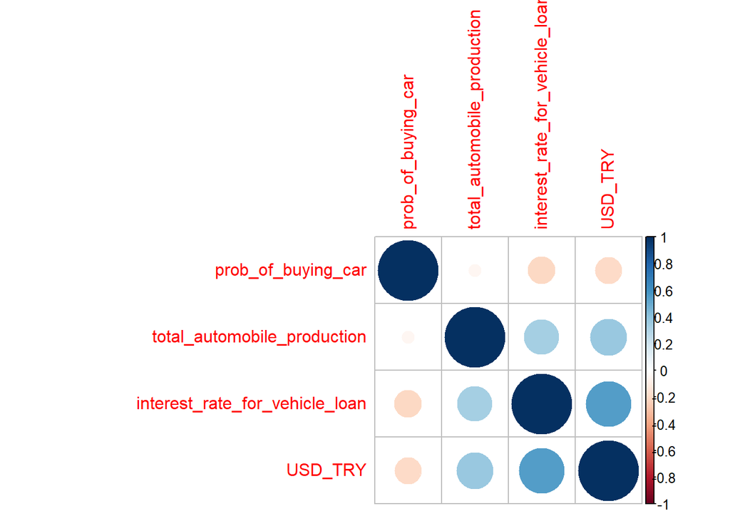

```r
M <- cor(df1[2:5])
corrplot::corrplot(M)
```

Although probability of buying a car does not have any strong correlation with these elements, there are some similarities observed in each section.